# Lab 03 - Data transformation

We also need to load the dataset we will use for this workshop, which are already uploaded in the RStudio Cloud project. To load it to your R session:

```r
load("data/data_workshop.Rdata")
```

The first thing to do when you load a dataset is to have a look at the data, to get familiar with the information they contain.

```r
plots
```

```
# A tibble: 11,858 x 9
   Codi  Provincia FccArb FechaIni   HoraIni             FechaFin
   <fct> <chr>      <int> <date>     <dttm>              <date>
 1 0800~ 08            70 2001-07-09 2017-11-26 09:44:00 2001-07-09
 2 0800~ 08            70 2001-08-06 2017-11-26 09:18:58 2001-08-06
 3 0800~ 08            80 2001-08-06 2017-11-26 12:08:09 2001-08-06
 4 0800~ 08            50 2001-07-09 2017-11-26 13:23:23 2001-07-09
 5 0800~ 08            60 2001-08-03 2017-11-26 09:11:28 2001-08-03
 6 0800~ 08            90 2001-08-01 2017-11-26 13:00:33 2001-08-01
 7 0800~ 08            90 2001-08-07 2017-11-26 10:08:15 2001-08-07
 8 0800~ 08            60 2001-08-03 2017-11-26 12:12:03 2001-08-03
 9 0800~ 08            70 2001-08-02 2017-11-26 09:00:16 2001-08-02
10 0800~ 08            80 2001-06-14 2017-11-26 12:34:21 2001-06-14
# ... with 11,848 more rows, and 3 more variables: HoraFin <dttm>,
#   PhSuelo <int>, FechaPh <date>
```

```r
trees
```

```
# A tibble: 111,756 x 10
   Codi   Provincia Especie Rumbo  Dist      N    CD DiamIf3 DiamIf2 HeiIf3
   <fct>  <chr>     <fct>   <dbl> <dbl>  <dbl> <dbl>   <dbl>   <dbl>  <dbl>
 1 080001 08        022         7  8.3   31.8     20    20.3    18.9    9
 2 080002 08        476        38  9.1   31.8     35    34      32.4    9
 3 080003 08        021        25  7     31.8     25    24.8    17.6   11
 4 080004 08        021        28  8.89  31.8     15    16.8    12.6    9.5
 5 080006 08        021        19 11.2   14.1     35    34.0    30.9   13
 6 080007 08        021        32 12     14.1     35    33.1    28.2   10
 7 080008 08        243        40  7.8   31.8     15    15      13.2    6
 8 080009 08        045        16  5.09  31.8     20    17.5    15.3    7
 9 080010 08        243        47 26.9    5.09    65    67.4    66.8   16.5
10 080013 08        022        44  2.7  127.      15    15.1    12.6    9.5
# ... with 111,746 more rows
```

We can get a slightly different view by using the `glimpse`function from the `tibble`package (included in the tidyverse)

```r
glimpse(trees)
```

```
Observations: 111,756
Variables: 10
$ Codi      <fct> 080001, 080002, 080003, 080004, 080006, 080007, 0800...
$ Provincia <chr> "08", "08", "08", "08", "08", "08", "08", "08", "08"...
$ Especie   <fct> 022, 476, 021, 021, 021, 021, 243, 045, 243, 022, 02...
$ Rumbo     <dbl> 7, 38, 25, 28, 19, 32, 40, 16, 47, 44, 13, 9, 9, 25,...
$ Dist      <dbl> 8.30, 9.10, 7.00, 8.89, 11.19, 12.00, 7.80, 5.09, 26...
$ N         <dbl> 31.83, 31.83, 31.83, 31.83, 14.14, 14.14, 31.83, 31....
$ CD        <dbl> 20, 35, 25, 15, 35, 35, 15, 20, 65, 15, 20, 30, 45, ...
$ DiamIf3   <dbl> 20.30, 34.00, 24.80, 16.85, 34.05, 33.10, 15.00, 17....
$ DiamIf2   <dbl> 18.90, 32.45, 17.55, 12.65, 30.90, 28.15, 13.25, 15....
$ HeiIf3    <dbl> 9.00, 9.00, 11.00, 9.50, 13.00, 10.00, 6.00, 7.00, 1...
```

For this lab we will mostly use the datasets `trees`, and plots, let’s see the variables that they contain:

**PLOTS**

This dataframe contains information on the plots measured in the National Forest Inventory

** TREES**

- Codi (factor): the code of the permanent plot.
- Provincia (character): the province in which the plot is located. For Catalonia the codes are:
  - Barcelona: “08”
  - Girona: “17”
  - Lleida: “25”
  - Tarragona “43”
- Especie (factor): the specific identity of the tree, as a code. You can find the meaning of each code [here](https://www.miteco.gob.es/es/biodiversidad/servicios/banco-datos-naturaleza/documentador_bdcampo_ifn3_tcm30-282240.pdf) (pages 24-28)
- Rumbo: the angle from the center of the plot to the tree, measured in centesimal degrees (so takes values from 0 to 400)
- Dist: the distance from the center of the plot to the tree, in meters
- N: number of trees per hectare that this tree represents
- CD: diameter class, in centimeters and grouped in 5 cm classes
- DiamIf3: tree diameter, in centimeters, as measured in IFN3
- DiamIf2: tree diameter, in centimeters, as measured in IFN2
- HeiIf3: tree height, in meters, as measured in IFN3.

# 1 Data transformation: create new variables, filter, select and organize data

We will use the package `dplyr` to transform our data frames in the way we need it in each case. With `dplyr` we can create new variables, select those of interest, execute filters, etc. The `dplyr` package contains 5 main verbs:

- `filter` will keep the rows that match a given set of conditions
- `select` will keep columns based on their name
- `arrange` will sort the data frame based on one or several variables
- `mutate` will create new variables
- `summarise` will create new variables that summarize values of an existing variable (mean, sum, etc.)

All of them, as most fuctions in the tidyverse, have a similar structure: the first argument in the function is the dataframe to which it will be applied, and the rest of arguments specify what to do with this dataframe, depending on the verb we are using. This is a common feature of the `tidyverse`, and also one of its strengths, because many functions share the same structure.

Also, it is important to note that the output of these functions will always be a dataframe (as is the input), and that they do not modify the original dataframe. That is, if we want to store the result of our process, we need to assign the operations to a given R object, that can be the original data frame (in this case, it will overwrite it) or a new one.

## 1.1 Retain observations with `filter`

`filter` selects those rows of a data frame that accomplish a certain criterion. The first argument is the data frame, and the rest are the criteria, that can be specified in chain, separated by commas.

For example, we can select all those plots that have been measured in Barcelona by typing:

```r
filter(plots, Provincia == "08")
```

```
# A tibble: 3,679 x 9
   Codi  Provincia FccArb FechaIni   HoraIni             FechaFin
   <fct> <chr>      <int> <date>     <dttm>              <date>
 1 0800~ 08            70 2001-07-09 2017-11-26 09:44:00 2001-07-09
 2 0800~ 08            70 2001-08-06 2017-11-26 09:18:58 2001-08-06
 3 0800~ 08            80 2001-08-06 2017-11-26 12:08:09 2001-08-06
 4 0800~ 08            50 2001-07-09 2017-11-26 13:23:23 2001-07-09
 5 0800~ 08            60 2001-08-03 2017-11-26 09:11:28 2001-08-03
 6 0800~ 08            90 2001-08-01 2017-11-26 13:00:33 2001-08-01
 7 0800~ 08            90 2001-08-07 2017-11-26 10:08:15 2001-08-07
 8 0800~ 08            60 2001-08-03 2017-11-26 12:12:03 2001-08-03
 9 0800~ 08            70 2001-08-02 2017-11-26 09:00:16 2001-08-02
10 0800~ 08            80 2001-06-14 2017-11-26 12:34:21 2001-06-14
# ... with 3,669 more rows, and 3 more variables: HoraFin <dttm>,
#   PhSuelo <int>, FechaPh <date>
```

**EXERCISE 1:**

To practice with `filter` let’s try to find those plots of IFN that:

- 1.1 Are located in Barcelona (08) or Girona (17). Hint: check the operators `|` and [`%in%`](http://www.datasciencemadesimple.com/in-operator-in-r/)

We have two options:

```r
# Option 1
    filter (plots, Provincia =="08" | Provincia =="17")
# Option 2
    filter (plots, Provincia %in% c("08", "17"))
```

```r
filter(plots, Provincia =="08" | "17")
```

```r
filter(gapminder, country == "Spain")
```

```
# A tibble: 12 x 6
   country continent  year lifeExp      pop gdpPercap
   <fct>   <fct>     <int>   <dbl>    <int>     <dbl>
 1 Spain   Europe     1952    64.9 28549870     3834.
 2 Spain   Europe     1957    66.7 29841614     4565.
 3 Spain   Europe     1962    69.7 31158061     5694.
 4 Spain   Europe     1967    71.4 32850275     7994.
 5 Spain   Europe     1972    73.1 34513161    10639.
 6 Spain   Europe     1977    74.4 36439000    13237.
 7 Spain   Europe     1982    76.3 37983310    13926.
 8 Spain   Europe     1987    76.9 38880702    15765.
 9 Spain   Europe     1992    77.6 39549438    18603.
10 Spain   Europe     1997    78.8 39855442    20445.
11 Spain   Europe     2002    79.8 40152517    24835.
12 Spain   Europe     2007    80.9 40448191    28821.
```

```r
filter(gapminder, year == 1997)
```

```
# A tibble: 142 x 6
   country     continent  year lifeExp       pop gdpPercap
   <fct>       <fct>     <int>   <dbl>     <int>     <dbl>
 1 Afghanistan Asia       1997    41.8  22227415      635.
 2 Albania     Europe     1997    73.0   3428038     3193.
 3 Algeria     Africa     1997    69.2  29072015     4797.
 4 Angola      Africa     1997    41.0   9875024     2277.
 5 Argentina   Americas   1997    73.3  36203463    10967.
 6 Australia   Oceania    1997    78.8  18565243    26998.
 7 Austria     Europe     1997    77.5   8069876    29096.
 8 Bahrain     Asia       1997    73.9    598561    20292.
 9 Bangladesh  Asia       1997    59.4 123315288      973.
10 Belgium     Europe     1997    77.5  10199787    27561.
# ... with 132 more rows
```

We can also use the operator `%in%` to select various cases

```r
filter(gapminder, country %in% c("Spain", "France", "Andorra"))
```

```
# A tibble: 24 x 6
   country continent  year lifeExp      pop gdpPercap
   <fct>   <fct>     <int>   <dbl>    <int>     <dbl>
 1 France  Europe     1952    67.4 42459667     7030.
 2 France  Europe     1957    68.9 44310863     8663.
 3 France  Europe     1962    70.5 47124000    10560.
 4 France  Europe     1967    71.6 49569000    13000.
 5 France  Europe     1972    72.4 51732000    16107.
 6 France  Europe     1977    73.8 53165019    18293.
 7 France  Europe     1982    74.9 54433565    20294.
 8 France  Europe     1987    76.3 55630100    22066.
 9 France  Europe     1992    77.5 57374179    24704.
10 France  Europe     1997    78.6 58623428    25890.
# ... with 14 more rows
```

### 1.1.1 `select`

`select` allows to retain only some columns, based on their name. As in `filter`, the first argument of `select`is a data frame, and the following arguments are the columns we want to keep.

```r
select(gapminder, country)
```

```
# A tibble: 1,704 x 1
   country
   <fct>
 1 Afghanistan
 2 Afghanistan
 3 Afghanistan
 4 Afghanistan
 5 Afghanistan
 6 Afghanistan
 7 Afghanistan
 8 Afghanistan
 9 Afghanistan
10 Afghanistan
# ... with 1,694 more rows
```

```r
select(gapminder, country, year, lifeExp)
```

```
# A tibble: 1,704 x 3
   country      year lifeExp
   <fct>       <int>   <dbl>
 1 Afghanistan  1952    28.8
 2 Afghanistan  1957    30.3
 3 Afghanistan  1962    32.0
 4 Afghanistan  1967    34.0
 5 Afghanistan  1972    36.1
 6 Afghanistan  1977    38.4
 7 Afghanistan  1982    39.9
 8 Afghanistan  1987    40.8
 9 Afghanistan  1992    41.7
10 Afghanistan  1997    41.8
# ... with 1,694 more rows
```

We can also decide which columns we DO NOT want to select by adding `-`before the name

```r
select(gapminder, -year)
```

```
# A tibble: 1,704 x 5
   country     continent lifeExp      pop gdpPercap
   <fct>       <fct>       <dbl>    <int>     <dbl>
 1 Afghanistan Asia         28.8  8425333      779.
 2 Afghanistan Asia         30.3  9240934      821.
 3 Afghanistan Asia         32.0 10267083      853.
 4 Afghanistan Asia         34.0 11537966      836.
 5 Afghanistan Asia         36.1 13079460      740.
 6 Afghanistan Asia         38.4 14880372      786.
 7 Afghanistan Asia         39.9 12881816      978.
 8 Afghanistan Asia         40.8 13867957      852.
 9 Afghanistan Asia         41.7 16317921      649.
10 Afghanistan Asia         41.8 22227415      635.
# ... with 1,694 more rows
```

To help us find the columns, there are some specific functions such as `starts_with` or `contains`, that only work within `select`. We can see the list of special functions by typing `help(select_helpers)`

```r
help(select_helpers)
```

### 1.1.2 `arrange`

`arrange` sorts the data frame based on the values of one or more variables (columns). The first argument will be, as usual, the data frame we want to sort, and then we must specify the variables that determine the ordering. If we specify more than 1 variable, the succesive variables will be used to decide order when there are ties (i.e. secondary sorting variables). We can also use `desc(x)` to sort in decreasing order.

```r
arrange(gapminder, lifeExp)
```

```
# A tibble: 1,704 x 6
   country      continent  year lifeExp     pop gdpPercap
   <fct>        <fct>     <int>   <dbl>   <int>     <dbl>
 1 Rwanda       Africa     1992    23.6 7290203      737.
 2 Afghanistan  Asia       1952    28.8 8425333      779.
 3 Gambia       Africa     1952    30    284320      485.
 4 Angola       Africa     1952    30.0 4232095     3521.
 5 Sierra Leone Africa     1952    30.3 2143249      880.
 6 Afghanistan  Asia       1957    30.3 9240934      821.
 7 Cambodia     Asia       1977    31.2 6978607      525.
 8 Mozambique   Africa     1952    31.3 6446316      469.
 9 Sierra Leone Africa     1957    31.6 2295678     1004.
10 Burkina Faso Africa     1952    32.0 4469979      543.
# ... with 1,694 more rows
```

```r
arrange(gapminder, desc(lifeExp))
```

```
# A tibble: 1,704 x 6
   country          continent  year lifeExp       pop gdpPercap
   <fct>            <fct>     <int>   <dbl>     <int>     <dbl>
 1 Japan            Asia       2007    82.6 127467972    31656.
 2 Hong Kong, China Asia       2007    82.2   6980412    39725.
 3 Japan            Asia       2002    82   127065841    28605.
 4 Iceland          Europe     2007    81.8    301931    36181.
 5 Switzerland      Europe     2007    81.7   7554661    37506.
 6 Hong Kong, China Asia       2002    81.5   6762476    30209.
 7 Australia        Oceania    2007    81.2  20434176    34435.
 8 Spain            Europe     2007    80.9  40448191    28821.
 9 Sweden           Europe     2007    80.9   9031088    33860.
10 Israel           Asia       2007    80.7   6426679    25523.
# ... with 1,694 more rows
```

```r
arrange(gapminder, desc(year), desc(lifeExp))
```

```
# A tibble: 1,704 x 6
   country          continent  year lifeExp       pop gdpPercap
   <fct>            <fct>     <int>   <dbl>     <int>     <dbl>
 1 Japan            Asia       2007    82.6 127467972    31656.
 2 Hong Kong, China Asia       2007    82.2   6980412    39725.
 3 Iceland          Europe     2007    81.8    301931    36181.
 4 Switzerland      Europe     2007    81.7   7554661    37506.
 5 Australia        Oceania    2007    81.2  20434176    34435.
 6 Spain            Europe     2007    80.9  40448191    28821.
 7 Sweden           Europe     2007    80.9   9031088    33860.
 8 Israel           Asia       2007    80.7   6426679    25523.
 9 France           Europe     2007    80.7  61083916    30470.
10 Canada           Americas   2007    80.7  33390141    36319.
# ... with 1,694 more rows
```

### 1.1.3 `mutate`

`mutate` allows us to create new variables with a certain value or as combination of existing variables. We just need to specify the data frame, and indicate the new variables name and its value, which can be related to existing variables:

```r
gdp_data <- mutate(gapminder,
                   fixed_num = 1,
                   number = 1:nrow(gapminder),
                   code = "foo",
                   gdp = ((gdpPercap * pop)/10^9))

gdp_data
```

```
# A tibble: 1,704 x 10
   country continent  year lifeExp    pop gdpPercap fixed_num number code
   <fct>   <fct>     <int>   <dbl>  <int>     <dbl>     <dbl>  <int> <chr>
 1 Afghan~ Asia       1952    28.8 8.43e6      779.         1      1 foo
 2 Afghan~ Asia       1957    30.3 9.24e6      821.         1      2 foo
 3 Afghan~ Asia       1962    32.0 1.03e7      853.         1      3 foo
 4 Afghan~ Asia       1967    34.0 1.15e7      836.         1      4 foo
 5 Afghan~ Asia       1972    36.1 1.31e7      740.         1      5 foo
 6 Afghan~ Asia       1977    38.4 1.49e7      786.         1      6 foo
 7 Afghan~ Asia       1982    39.9 1.29e7      978.         1      7 foo
 8 Afghan~ Asia       1987    40.8 1.39e7      852.         1      8 foo
 9 Afghan~ Asia       1992    41.7 1.63e7      649.         1      9 foo
10 Afghan~ Asia       1997    41.8 2.22e7      635.         1     10 foo
# ... with 1,694 more rows, and 1 more variable: gdp <dbl>
```

```r
arrange(gdp_data, desc(year), desc(gdp))
```

```
# A tibble: 1,704 x 10
   country continent  year lifeExp    pop gdpPercap fixed_num number code
   <fct>   <fct>     <int>   <dbl>  <int>     <dbl>     <dbl>  <int> <chr>
 1 United~ Americas   2007    78.2 3.01e8    42952.         1   1620 foo
 2 China   Asia       2007    73.0 1.32e9     4959.         1    300 foo
 3 Japan   Asia       2007    82.6 1.27e8    31656.         1    804 foo
 4 India   Asia       2007    64.7 1.11e9     2452.         1    708 foo
 5 Germany Europe     2007    79.4 8.24e7    32170.         1    576 foo
 6 United~ Europe     2007    79.4 6.08e7    33203.         1   1608 foo
 7 France  Europe     2007    80.7 6.11e7    30470.         1    540 foo
 8 Brazil  Americas   2007    72.4 1.90e8     9066.         1    180 foo
 9 Italy   Europe     2007    80.5 5.81e7    28570.         1    780 foo
10 Mexico  Americas   2007    76.2 1.09e8    11978.         1    996 foo
# ... with 1,694 more rows, and 1 more variable: gdp <dbl>
```

As we see, we can combine `mutate` and `arrange` to know which are the richest countries in the world (in terms of gdp).

### 1.1.4 `summarise`

`summarise` allows us to make calculations with the variables in the data frame, but using *summary functions*, i.e. functions that transform the variability in a given variable into a single value. Functions such as `sum`, `mean`, `max`,`IQR`, etc. are examples of summary functions.

```r
summarise(gapminder, mean_life = mean(lifeExp))
```

```
# A tibble: 1 x 1
  mean_life
      <dbl>
1      59.5
```

However, this function by itself often lacks any interest, cause it would reduce all the data frame to a single value. It is commonly used together with `group_by`, that classifies the data frame in groups based on a categorical variable.

To use `group_by` we just need to indicate the data frame and the variable we want to group it by. To be more efficient, `dplyr` does not create a copy of the data frame, but it creates a hidden variable that indexes the groups, so that when we ask it to perform operations by group, it know to which group belongs each observation.

In the case of our data frame `gapminder`, there are several groups that could be of interest:

```r
# By year
by_year <- group_by (gapminder, year)

# By country
by_country <- group_by (gapminder, country)

# By continent
by_continent <- group_by (gapminder, continent)

# By country and year
by_country_year <- group_by(gapminder, country, year)

# By continent and year
by_continent_year <- group_by (gapminder, continent, year)
```

We can see, by typing `glimpse(by_country)` that the resulting data frame is not different at all from the original, at least apparently. However, if we type `class(by_country)` we see it has now a new class `grouped_df`.

```r
glimpse(by_country)
```

```
Observations: 1,704
Variables: 6
$ country   <fct> Afghanistan, Afghanistan, Afghanistan, Afghanistan, ...
$ continent <fct> Asia, Asia, Asia, Asia, Asia, Asia, Asia, Asia, Asia...
$ year      <int> 1952, 1957, 1962, 1967, 1972, 1977, 1982, 1987, 1992...
$ lifeExp   <dbl> 28.801, 30.332, 31.997, 34.020, 36.088, 38.438, 39.8...
$ pop       <int> 8425333, 9240934, 10267083, 11537966, 13079460, 1488...
$ gdpPercap <dbl> 779.4453, 820.8530, 853.1007, 836.1971, 739.9811, 78...
```

```r
class(by_country)
```

```
[1] "grouped_df" "tbl_df"     "tbl"        "data.frame"
```

Now we can compute summary statistics that are way more interesting:

```r
summarise(by_continent, life= median(lifeExp))
```

```
# A tibble: 5 x 2
  continent  life
  <fct>     <dbl>
1 Africa     47.8
2 Americas   67.0
3 Asia       61.8
4 Europe     72.2
5 Oceania    73.7
```

```r
summarise(by_continent_year, life= median(lifeExp))
```

```
# A tibble: 60 x 3
# Groups:   continent [?]
   continent  year  life
   <fct>     <int> <dbl>
 1 Africa     1952  38.8
 2 Africa     1957  40.6
 3 Africa     1962  42.6
 4 Africa     1967  44.7
 5 Africa     1972  47.0
 6 Africa     1977  49.3
 7 Africa     1982  50.8
 8 Africa     1987  51.6
 9 Africa     1992  52.4
10 Africa     1997  52.8
# ... with 50 more rows
```

```r
summarise(by_continent_year, gdp = mean(gdpPercap))
```

```
# A tibble: 60 x 3
# Groups:   continent [?]
   continent  year   gdp
   <fct>     <int> <dbl>
 1 Africa     1952 1253.
 2 Africa     1957 1385.
 3 Africa     1962 1598.
 4 Africa     1967 2050.
 5 Africa     1972 2340.
 6 Africa     1977 2586.
 7 Africa     1982 2482.
 8 Africa     1987 2283.
 9 Africa     1992 2282.
10 Africa     1997 2379.
# ... with 50 more rows
```

# 2 Pipelines (`%>%`)

We will often use several `dplyr` verbs together, creating nested functions. However, when we need to perform several operations, these nested functions can easily get complex and difficult to understand. For example, by having a look at this code, would you be able to say what it will do?

```r
diam_medio_especie <- filter(
    summarise(
        group_by(
            filter(
                trees,
                !is.na(DiamIf3)
            ),
        Codi, Especie
        ),
    diam = mean (DiamIf3),
    n = n()
    ),
n > 5)
```

Although this syntaxis is not operationally complex, it is hard to understand. Often a solution is to save each step as a different data frame, but this is an important source of errors.

We can however simplify this code using the *pipe* operator (`%>%`) from the `magrittr` package, which is installed and loaded with `tidyr` and `dplyr`. When we use `%>%`, the result of the left side is processed by the righ side function as first argument. In the case of `dplyr` and `tidyr`, since the first argument is always a data frame, `%>%` makes that a function be applied to the data frame resulting from the previous function. Thus, we can express `filter (df, color =="blue)` as `df %>% filter(color == "blue")`. This allows to concatenate several functions in a logical and understandable way, so that the operator `%>%` could be read as *then*. Let’s see how this would be in the previous function

```r
diam_medio_especie <- trees %>%             # take the df 'trees' and THEN
filter(!is.na(DiamIf3)) %>%                 # eliminate NA values and THEN
group_by(Codi, Especie) %>%                 # group y plot and species and THEN
summarise(diam=mean(DiamIf3), n = n()) %>%  # calculate mean and number of trees and THEN
filter(n > 5)                               # filter those with n> 5
```

Exercise 6 Let’s do some exercises. Using the pipe operator, let’s create pipelines to solve the next exercises:

- Ex.6.1 Which plots have the greatest average growth between IFN2 and IFN3?

We first define the data frame we will work with. *THEN* (`%>%`) we create a new variable with the growth of each tree, *THEN* we group by plot, *THEN* we calculate, for each plot, the mean growth, and *THEN* we arrange the results in decreasing order. The resulting code would be:

```r
trees %>%
    mutate(growth=DiamIf3-DiamIf2) %>%
    group_by(Codi) %>%
    summarise(av_growth=mean(growth), n=n()) %>%
    arrange(desc(av_growth))
```

```
# A tibble: 7,713 x 3
   Codi   av_growth     n
   <fct>      <dbl> <int>
 1 171089      23.1     3
 2 170819      21.6     1
 3 172607      17.6     6
 4 172216      17.4     6
 5 172690      16.0    17
 6 171682      15.4     6
 7 083267      15.3     1
 8 431363      15.1     4
 9 171664      14.8     5
10 171976      14.4     1
# ... with 7,703 more rows
```

- Ex.6.2 Which is the plot with highest species richness?

First, we define thedata frame (`trees`), *THEN* we group by Code, *THEN* we determine the number of species per plot and *THEN* we arrange in decreasing order:

```r
trees %>%
    group_by(Codi) %>%
    summarise (n_species=n_distinct(Especie)) %>%
    arrange(desc(n_species))
```

```
# A tibble: 7,713 x 2
   Codi   n_species
   <fct>      <int>
 1 170195         9
 2 171036         9
 3 170218         8
 4 170121         7
 5 170596         7
 6 170635         7
 7 170799         7
 8 171398         7
 9 171481         7
10 172650         7
# ... with 7,703 more rows
```

- Ex.6.3 Are both variables (species richness and average growth) related?

First, we would need to indicate the data frame we will work with, *THEN* we will group by plot, *THEN* we will calculate the variables. To see the relationship between both variables, we will create a plot with `ggplot2`, just to show how all the packages in the tidyverse relate to each other. The aim of this workshop is not to learn `ggplot2`, so we won’t go into further details. To know more about ggplot you can visit this website: http://ggplot2.org/.

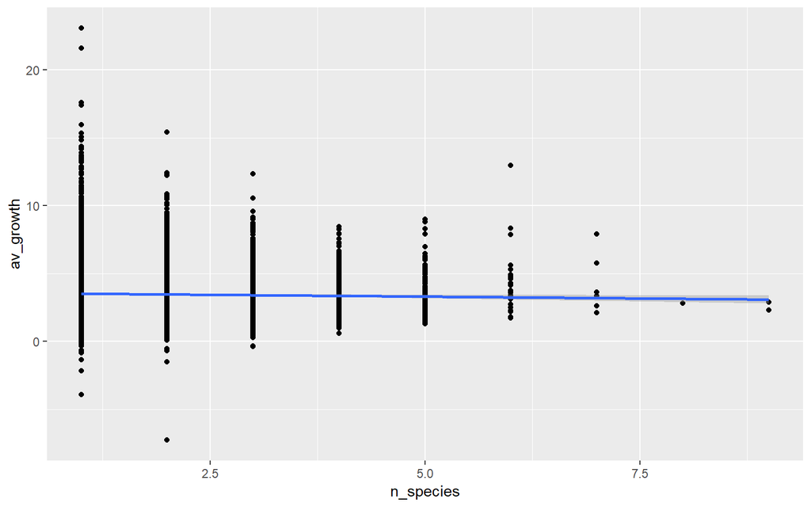

```r
trees %>%
    mutate(growth=DiamIf3-DiamIf2) %>%
    group_by(Codi) %>%
        summarise (n_species=n_distinct(Especie),
                   av_growth=mean(growth)) %>%
    ggplot(aes(n_species, av_growth)) +
    geom_point() +
    geom_smooth(method = "lm")
```

Here we see one of the advantages of the `tidyverse`, the fact that all the packages and functions can communicate one with another. In this way, we just created a plot without the need of creating intermediate objects or data frames, starting directly from the raw data frame, and chianing orders in a logical and intuitive way.

# 3 Grouped mutate/grouped filter

Most of the times we use `group_by`, we will do it with the *summary functions*, that is, functions that take n values as input, and give back 1 value as output. Examples of *summary functions* are `mean()`, `sd()`, `min()`, `sum()`, etc.

However, some times we will need to do some operation by group, but we will need to produce one output per input, that is n inputs –> n outputs. This can be done using `mutate` or `filter` in combination with `group_by`.

### 3.0.1 Exercise 7

Taking this into account, let’s try to:

- Ex.7.1 Identify those trees that grow much faster than the average of the plot

```r
trees %>%
    mutate(growth=DiamIf3-DiamIf2) %>%
    group_by(Codi) %>%
    mutate(plot_mean= mean(growth),
           des = (growth - plot_mean)) %>%
    arrange(desc(des))
```

- Ex. 7.2 Identify those plots where a species grows much more than the average for the species

```r
trees %>%
    mutate(growth=DiamIf3-DiamIf2) %>%
    group_by(Especie) %>%
    mutate(growth_sp = mean(growth)) %>%
    group_by(Codi, Especie) %>%
    mutate(growth_sp_plot = mean(growth),
           inc = (growth_sp_plot /growth_sp))%>%
    arrange(desc(inc))
```

As we did before, we first calculate the growth of eaxh tree, we then group by species, so that we can calculate the mean growth for each species (`growth_sp`). Finally, we group again, now for plot and species, to calculate the mean growth of each species on each plot (`growth_sp_plot`). Once we have this, we can calculate the ratio between the two variables, identifying those plots where the species is performing better )assuming no mistakes, of course).

Let’s see one last example:

*Ex.7.3 Select those species of the IFN3 occupied by “pure” Pinus nigra stands (Especie = 025) Note: a forest is considered as pure stand if more than 80% of their Basal Area corresponds to a single species. Let’s see how we would do that:

```r
# trees %>%
#     group_by(Codi,Especie) %>%
#     summarise(BA_sp= sum(BAIf3)) %>%
#     group_by(Codi) %>%
#     mutate(BA_tot = sum(BA_sp),
#            ratio= BA_sp/BA_tot) %>%
#     filter(Especie=="025", ratio >0.8)
```

## 3.1 Mutating joins

They add the columns of a data frame to the other, depending on whether they share some observations or not. There are four types.

- `left_join(x, y)` adds the columns of `y` to the observations of `x` that are also in `y`. Those that are not present in y will receive the value `NA`. With this function we ensure that we will not lose any observation.
- `right_join(x, y)` adds the columns of `x` to those observations in `y` that are also in `x`. Those that are not present will receive `NA`. It is equivalent to `left_join`, but the columns will be ordered differently.
- `full_join(x,y)` includes all observations in `x` and `y`. If they do not coincide, they assign `NA`.
- `inner_join(x, y)` includes only those observations both in `x` and `y` (repeats rows if it is necessary).

## 3.2 Filtering joins

The second type of joins are the **filtering joins**, that affect only to the observation, not to the variables. That is, they never add new columns, but they keep or delete the rows of the original frame as a function of their correspondence or not with a second data frame. There are only two types:

- `semi_join(x, y)` *keeps* the observations in `x` that match observations in `y`.
- `anti_join(x, y)` *deletes* the observations in `x` that match observations in `y`.

You can find more information about the join functions typing `vignette("two-table")`.

### 3.2.1 Exercise 8

To try the join functions, let’s add the geographic information (X & Y coordinates), contained in the data frame `coordinates` to the data frame `plots`.

```r
left_join(plots,coordinates, "Codi")
```

In this case, since we want to keep all the plots in the original `plots`data frame, we use `left_join`. In this case, since the number of observations in `coordinates` and `plots` is the same, the function `inner_join` should give us the same results.

Now we added the coordinates, we can represent in a map any variable in the data frame. We could, for example, represent the values of tree canopy cover (FccArb). We need to load the package “maps”. (If we don’t have it installed, we can install it typing in the console `install.packages("maps")`).

```r
library(maps)
```

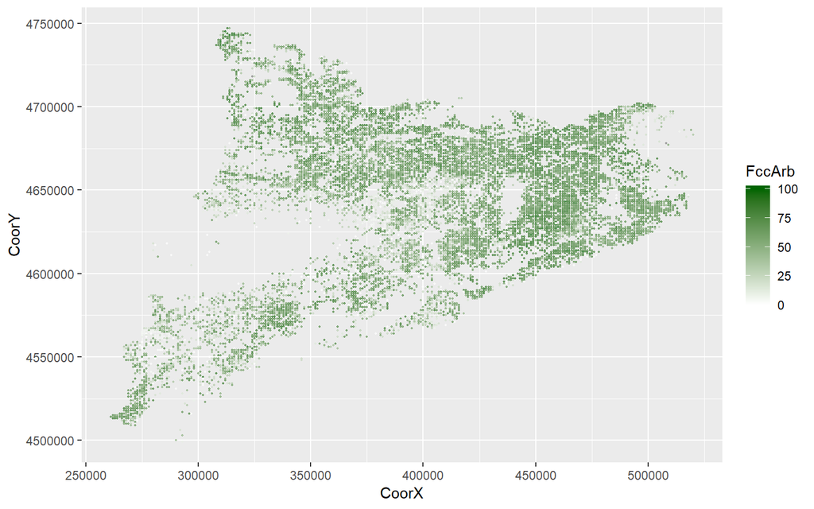

```r
left_join(plots,coordinates, "Codi") %>%
ggplot( aes(CoorX, CoorY)) +
    geom_point(aes(color=FccArb), size=0.3, alpha=0.6) +
    scale_color_continuous(low= "white", high="dark green")
```

Once again, we see we don’t even need to create a new data frame with the new information, we can chain the functions in `dplyr` and `ggplot2`, producing the results in a very easy and fast way.